# Red Wine Data Anlaysis by Fan Liu

## About

In this project, I will explore a data set on red wine quality and physicochemical properties. The objective is to explore which chemical properties influence the quality of red wines. This dataset is public available for research.

### Summary of data

Let’s check the basic information for the statistics

```
##   X fixed.acidity volatile.acidity citric.acid residual.sugar chlorides
## 1 1           7.4             0.70        0.00            1.9     0.076
## 2 2           7.8             0.88        0.00            2.6     0.098
## 3 3           7.8             0.76        0.04            2.3     0.092
## 4 4          11.2             0.28        0.56            1.9     0.075
## 5 5           7.4             0.70        0.00            1.9     0.076
## 6 6           7.4             0.66        0.00            1.8     0.075
##   free.sulfur.dioxide total.sulfur.dioxide density   pH sulphates alcohol
## 1                  11                   34  0.9978 3.51      0.56     9.4
## 2                  25                   67  0.9968 3.20      0.68     9.8
## 3                  15                   54  0.9970 3.26      0.65     9.8
## 4                  17                   60  0.9980 3.16      0.58     9.8
## 5                  11                   34  0.9978 3.51      0.56     9.4
## 6                  13                   40  0.9978 3.51      0.56     9.4
##   quality
## 1       5
## 2       5
## 3       5
## 4       6
## 5       5
## 6       5
```

```
## 'data.frame':    1599 obs. of  13 variables:
##  $ X                   : int  1 2 3 4 5 6 7 8 9 10 ...
##  $ fixed.acidity       : num  7.4 7.8 7.8 11.2 7.4 7.4 7.9 7.3 7.8 7.5 ...
##  $ volatile.acidity    : num  0.7 0.88 0.76 0.28 0.7 0.66 0.6 0.65 0.58 0.5 ...
##  $ citric.acid         : num  0 0 0.04 0.56 0 0 0.06 0 0.02 0.36 ...
##  $ residual.sugar      : num  1.9 2.6 2.3 1.9 1.9 1.8 1.6 1.2 2 6.1 ...
##  $ chlorides           : num  0.076 0.098 0.092 0.075 0.076 0.075 0.069 0.065 0.073 0.071 ...
##  $ free.sulfur.dioxide : num  11 25 15 17 11 13 15 15 9 17 ...
##  $ total.sulfur.dioxide: num  34 67 54 60 34 40 59 21 18 102 ...
##  $ density             : num  0.998 0.997 0.997 0.998 0.998 ...
##  $ pH                  : num  3.51 3.2 3.26 3.16 3.51 3.51 3.3 3.39 3.36 3.35 ...
##  $ sulphates           : num  0.56 0.68 0.65 0.58 0.56 0.56 0.46 0.47 0.57 0.8 ...
##  $ alcohol             : num  9.4 9.8 9.8 9.8 9.4 9.4 9.4 10 9.5 10.5 ...
##  $ quality             : int  5 5 5 6 5 5 5 7 7 5 ...
```

```
##        X          fixed.acidity   volatile.acidity  citric.acid
##  Min.   :   1.0   Min.   : 4.60   Min.   :0.1200   Min.   :0.000
##  1st Qu.: 400.5   1st Qu.: 7.10   1st Qu.:0.3900   1st Qu.:0.090
##  Median : 800.0   Median : 7.90   Median :0.5200   Median :0.260
##  Mean   : 800.0   Mean   : 8.32   Mean   :0.5278   Mean   :0.271
##  3rd Qu.:1199.5   3rd Qu.: 9.20   3rd Qu.:0.6400   3rd Qu.:0.420
##  Max.   :1599.0   Max.   :15.90   Max.   :1.5800   Max.   :1.000
##  residual.sugar     chlorides       free.sulfur.dioxide
##  Min.   : 0.900   Min.   :0.01200   Min.   : 1.00
##  1st Qu.: 1.900   1st Qu.:0.07000   1st Qu.: 7.00
##  Median : 2.200   Median :0.07900   Median :14.00
##  Mean   : 2.539   Mean   :0.08747   Mean   :15.87
##  3rd Qu.: 2.600   3rd Qu.:0.09000   3rd Qu.:21.00
##  Max.   :15.500   Max.   :0.61100   Max.   :72.00
##  total.sulfur.dioxide    density             pH          sulphates
##  Min.   :  6.00       Min.   :0.9901   Min.   :2.740   Min.   :0.3300
##  1st Qu.: 22.00       1st Qu.:0.9956   1st Qu.:3.210   1st Qu.:0.5500
##  Median : 38.00       Median :0.9968   Median :3.310   Median :0.6200
##  Mean   : 46.47       Mean   :0.9967   Mean   :3.311   Mean   :0.6581
##  3rd Qu.: 62.00       3rd Qu.:0.9978   3rd Qu.:3.400   3rd Qu.:0.7300
##  Max.   :289.00       Max.   :1.0037   Max.   :4.010   Max.   :2.0000
##     alcohol         quality
##  Min.   : 8.40   Min.   :3.000
##  1st Qu.: 9.50   1st Qu.:5.000
##  Median :10.20   Median :6.000
##  Mean   :10.42   Mean   :5.636
##  3rd Qu.:11.10   3rd Qu.:6.000
##  Max.   :14.90   Max.   :8.000
```

## Univariate Plots Section

Checking the main response variable’s distribution

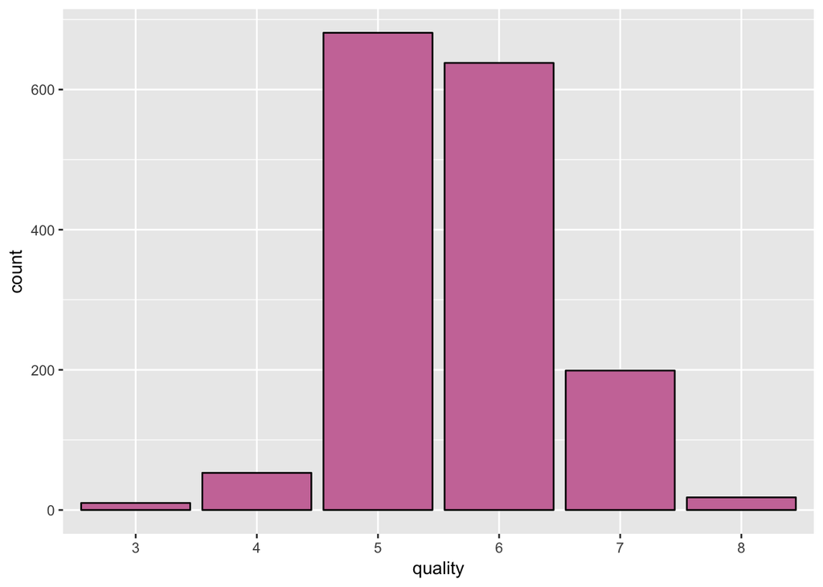

By observing the distribution of “quality” we can see it is approximately normal distribution, and there are no obvious outliers.

## Add Another Feature

Arrange the quality into three groups: bad,average,good.

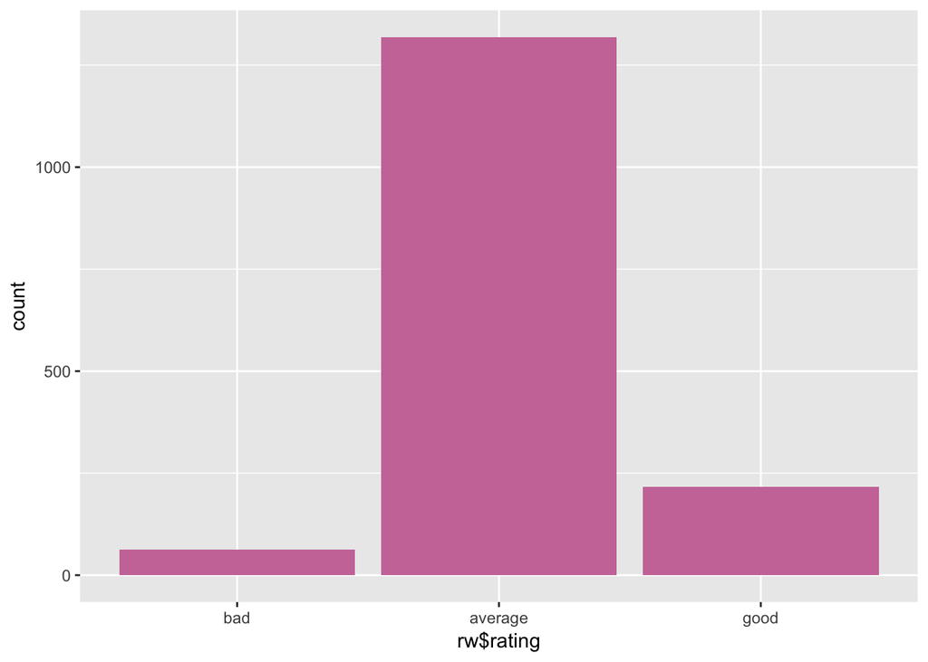

Checking other variables’ distribution

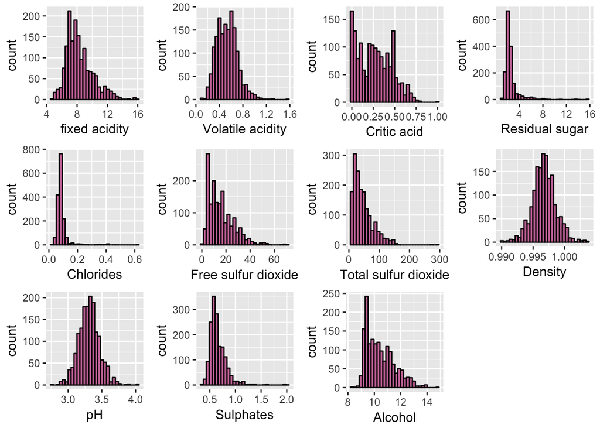

### Find outliers

The graphs above show the distributions of each explanatory variable:

- Variables “fixed.acidity”, “Volatile.acidity”, “Density”, and “pH” are approximate  
  normally distributed.
- Variables “Residual sugar”,“Free sulfur dioxide”,“Total sulfur dioxide”,“Sulphates” and “Alcohol” is right skewed.
- Variables “Critic.acid”,and“Chlorides” are hard to tell distributions.

There should be outliers in some of the variables, hence let’s check out the outliers.

| Variable | Number of outliers |
| --- | --- |
| total.sulfur.dioxide | 55 |
| sulphates | 59 |
| alcohol | 13 |
| citric.acid | 1 |
| residual.sugar | 155 |
| chlorides | 112 |
| free.sulfur.dioxide | 30 |

The table above shows that “residual.sugar”" and “chlorides” have significance amout of outliers.What’s more,since some of the variables are higly skewed based on the histograms. Hence, log_scales need to be done when plotting.

### Rescale variables

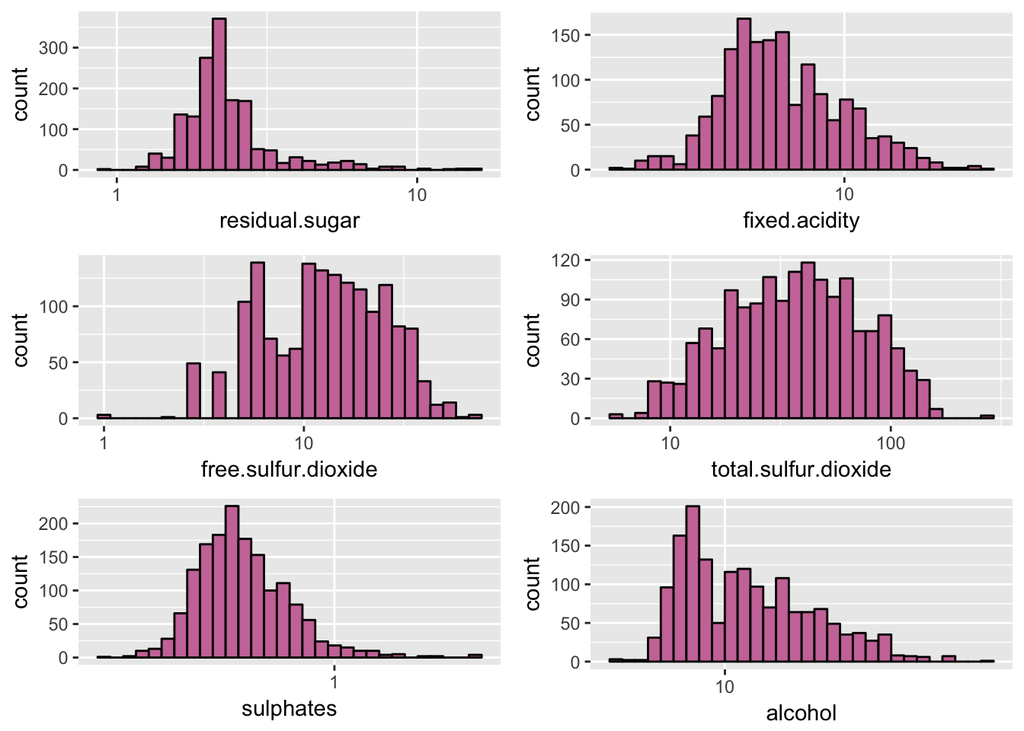

Compare to the formal histograms, graphs after rescale_x seem to approximately normally distributed.

## Univarite Plot Analysis

#### What is the structure of your dataset?

There are 1599 observations in the dataset with 13 features:

Input variables:

- X
- fixed acidity (tartaric acid - g / dm^3)
- volatile acidity (acetic acid - g / dm^3)
- citric acid (g / dm^3)
- residual sugar (g / dm^3)
- chlorides (sodium chloride - g / dm^3)
- free sulfur dioxide (mg / dm^3)
- total sulfur dioxide (mg / dm^3)
- density (g / cm^3)
- pH
- sulphates (potassium sulphate - g / dm3)
- alcohol (% by volume)

Output variable (based on sensory data):

- quality (score between 0 and 10).

#### What is/are the main feature(s) of interest in your dataset?

The main feature in the dataset is quality. I’d like to determine which features have stronger influences on red wine quality.

#### What other features in the dataset do you think will help support your investigation into your feature(s) of interest?

I think the features like pH, density, citric.acid, volatile.acid and sulphates would help support my investigation, because I think the quality of the red wine is highly related to those variables.

#### Did you create any new variables from existing variables in the dataset?

Yes, I create the rating variable based on the wine quality.

#### Of the features you investigated, were there any unusual distributions? Did you perform any operations on the data to tidy, adjust, or change the form of the data? If so, why did you do this?

Yes, there were some unusual distributions. I did the scale_x_log10 to them. After I did the transformation, those variables are becoming from right skewed data to the approximately normal distribution.

## Bivariate Plots Section

Let’s find the correlations between quality and other 11 varibales. First, let’s investigate the correlation between each varibale.

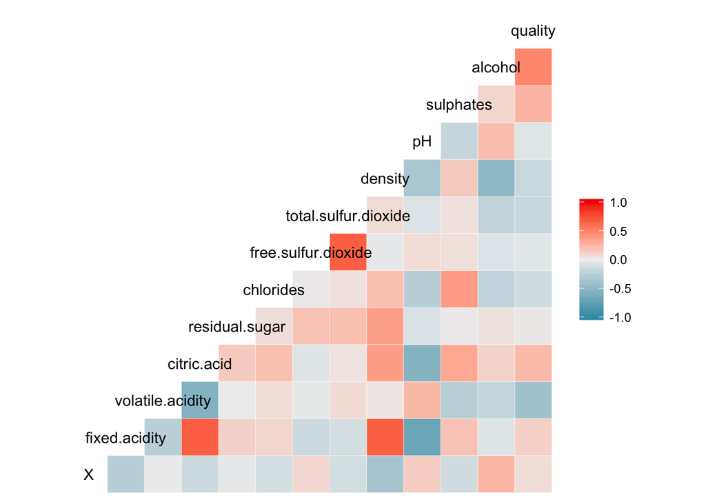

By obseving the graph above, we can have the following

### A table that contains correlation between quality and other 11 variables

| Variables | Correlation Value |
| --- | --- |
| Fixed acidity | 0.124 |
| Volatile acidity | -0.391 |
| Citric.acidity | 0.226 |
| Residual sugar | 0.024 |
| Chlorides | -0.176 |
| Free sulfur dioxide | -0.050 |
| Total sulfur dioxide | -0.170 |
| Dencity | -0.175 |
| pH | -0.058 |
| Sulphates | 0.309 |
| Alcohol | 0.477 |

## Bivarite Plot Analysis

We can see that correlations of “Volatitle acidity”, “Citric.acidity”,“Sulphates”,and “Alcohol” are bigger than 0.2 or -0.2, which indicate that these four varibales have more influences on “quality”. However, correlation between “citric.acidity” and “Volatitle.acidity” has a relatively strong negative correlation, so it is multicollinearity, then we want to use only one of the variable to do the prediction. In here, I will choose Volatitle.acidity.

#### Talk about some of the relationships you observed in this part of the investigation. How did the feature(s) of interest vary with other features in the dataset?

- By observing these graphs, we can see that the higher the alcohol content, the greater the wine quality.
- It is the same for citric.acid and sulphates. They all have the posotive correlation with wine quality.
- However, volatile acidity has a negetive correlation with wine quality.
- Fixed.acidity seems to have little to no effect on quality

## Multivariate Plots Section

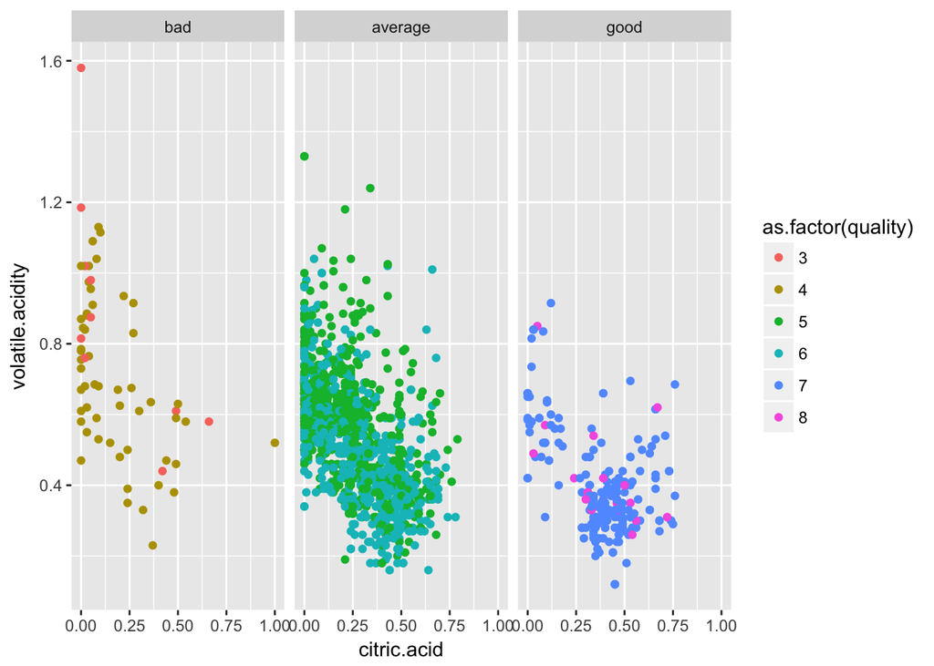

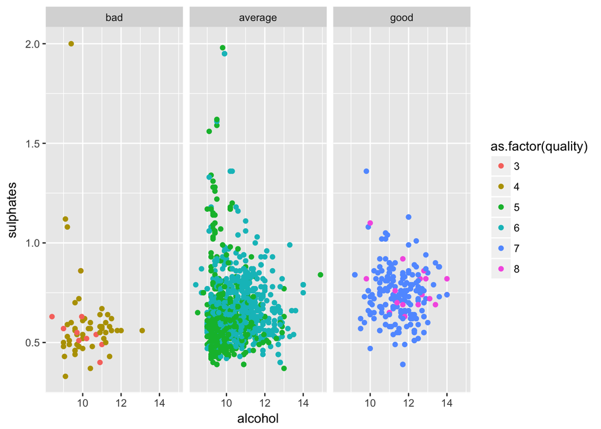

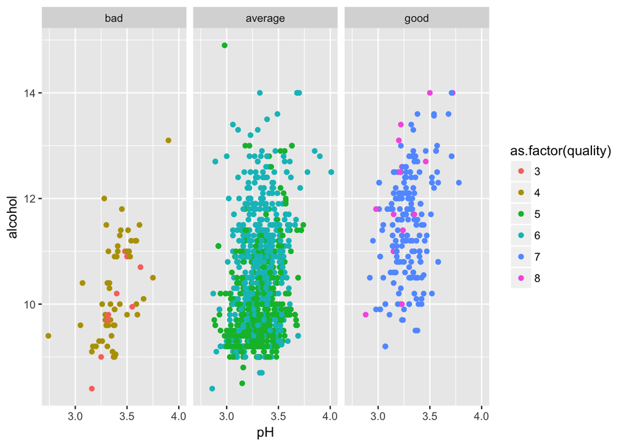

## Multivariate Analysis

#### Talk about some of the relationships you observed in this part of the investigation. Were there features that strengthened each other in terms of looking at your feature(s) of interest?

By observing the multivariate plots we can see that, among the other features, there are not strong correlations.

But we can have the following observations: * The higher the ctric acid with a lower volatile turns out to be a better quality of wine. * Alcohol and sulphates do not have any relations. * High alcohol contents and high sulphate concentrations combined seem to produce better wines.

#### Were there any interesting or surprising interactions between features?

I am actually surprise that there is a negative relation between sulphate and volatile.acidity.

## Final Plots and Summary

#### Plot one: Effects of alcohol on wine quality

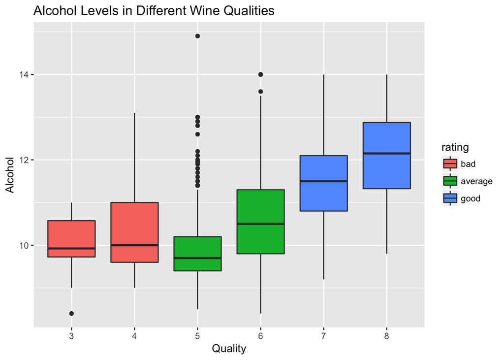

By observing the graph above, we can see that a highrt alcohol density tends to make a better wine.

#### Plot two： Effects of sulphates and alcohol on wine quality

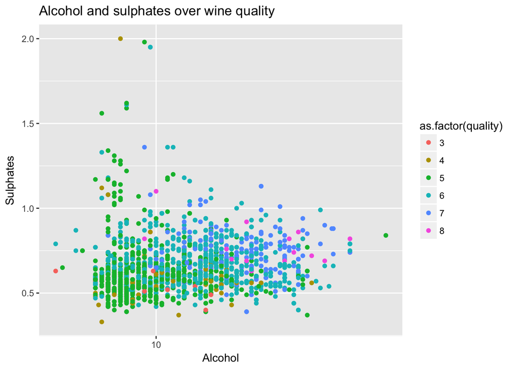

#### Plot three:

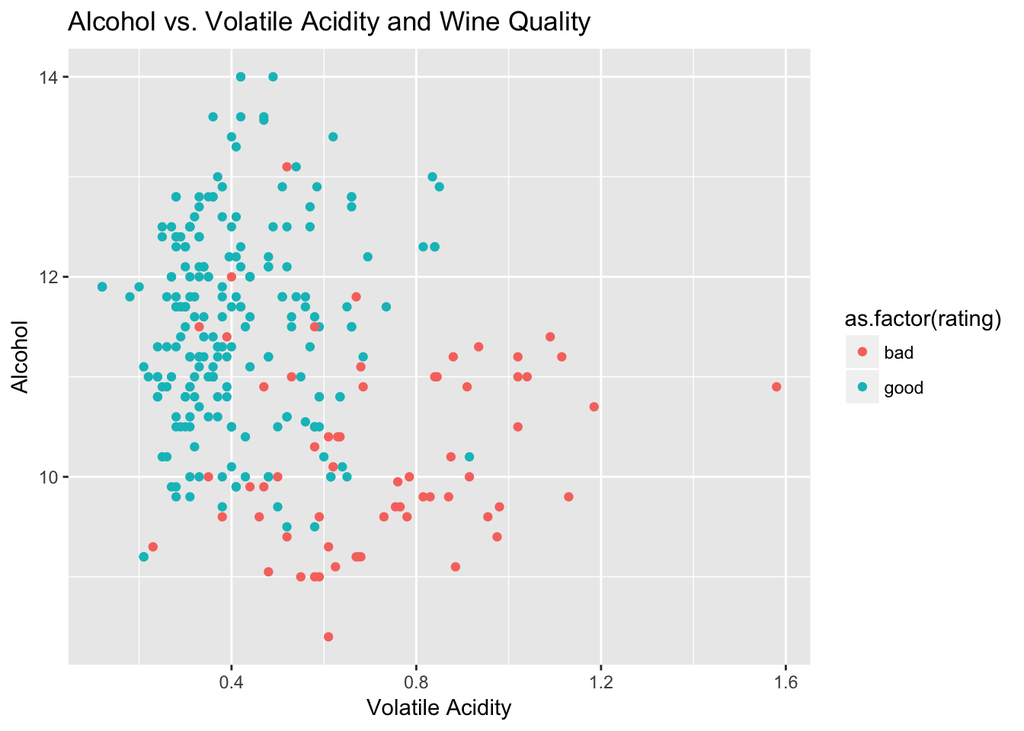

As the correlation tests show, wine quality was affected most strongly by alcohol and volaticle acidity.

## Reflection

Through this exploratory, I found that there are four main features would influence the wine quality. They are: alcohol, sulphates, volatile acidity and citric acid. Among these four main features, alcohol concentration, sulphates and citric acidity are all have the positive correlation with wine quality. Volatile acidity has the negative relation with wine quality. By looking at the univarite plots, we can see that some of the variables are right skewed or with long tails. Then I make the log-transformation. The graphs adequately illustrate the factors that make good wines ‘good’ and bad wines ‘bad’.

By finishing this graph, I encounter the problems of definying outliers. However, used google to figure it out.I used scale when I was doing ploting, but use the original data to do the analysis.